# Stock_Analysis

```python
import pandas as pd

# Load the uploaded file

df = pd.read_csv(r'C:\Users\Dell\Downloads\stock.csv')

# Convert the 'Date' column to datetime
df['Date'] = pd.to_datetime(df['Date'])

# Set 'Date' as the index
df.set_index('Date', inplace=True)

df.head()
```

| Date | Open | High | Low | Close | Adj Close | Volume |
| --- | --- | --- | --- | --- | --- | --- |
| 2018-02-05 | 262.000000 | 267.899994 | 250.029999 | 254.259995 | 254.259995 | 11896100 |
| 2018-02-06 | 247.699997 | 266.700012 | 245.000000 | 265.720001 | 265.720001 | 12595800 |
| 2018-02-07 | 266.579987 | 272.450012 | 264.329987 | 264.559998 | 264.559998 | 8981500 |
| 2018-02-08 | 267.079987 | 267.619995 | 250.000000 | 250.100006 | 250.100006 | 9306700 |
| 2018-02-09 | 253.850006 | 255.800003 | 236.110001 | 249.470001 | 249.470001 | 16906900 |

## Correlation Matrix Heatmap

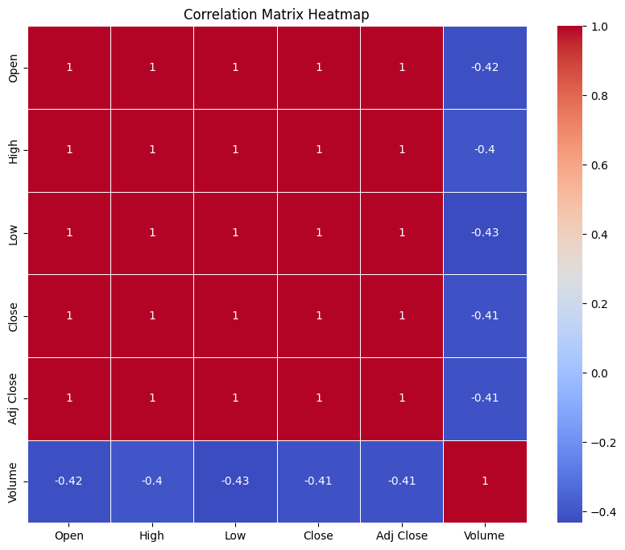

```python
import matplotlib.pyplot as plt
import seaborn as sns

# Calculate the correlation matrix
correlation_matrix = df.corr()

# Plot the correlation matrix heatmap
plt.figure(figsize=(10, 8))
sns.heatmap(correlation_matrix, annot=True, cmap='coolwarm', linewidths=0.5)
plt.title('Correlation Matrix Heatmap')
plt.show()
```

The heatmap of the correlation matrix provides a visual representation of the relationships between different variables in the stock market data. Here's an explanation of the key observations from the heatmap:

This heatmap helps traders, investors, and analysts to understand how different stock market variables move together, providing insights that can aid in making informed trading decisions.

## Stock Price and Volume Over Time

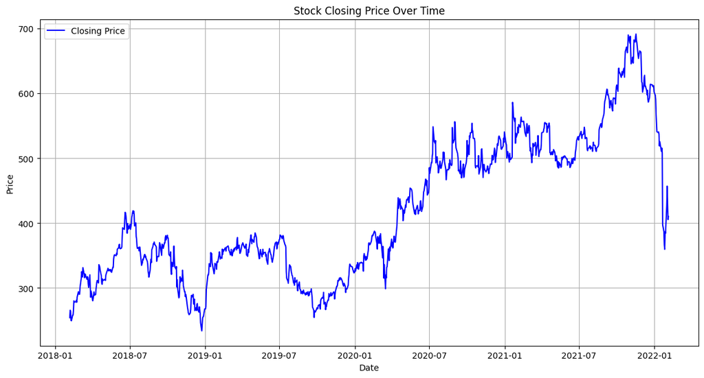

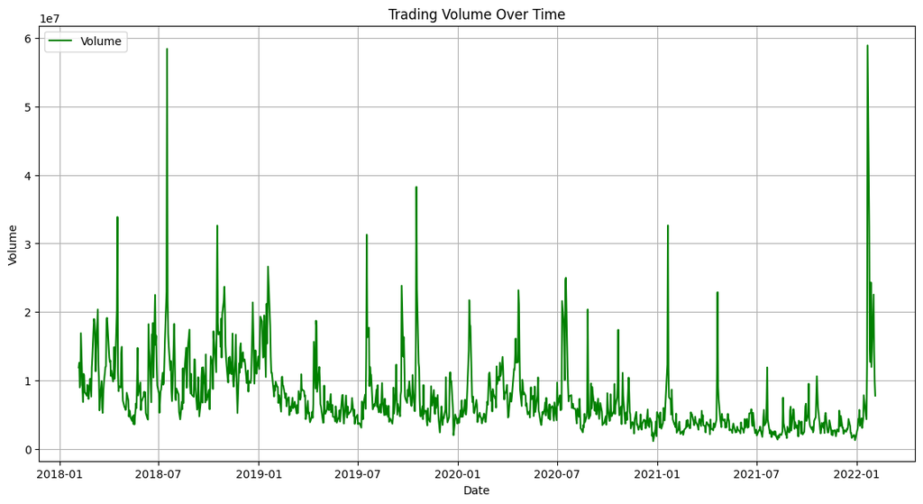

```python
# Plot the closing price over time
plt.figure(figsize=(14, 7))
plt.plot(df.index, df['Close'], label='Closing Price', color='blue')
plt.title('Stock Closing Price Over Time')
plt.xlabel('Date')
plt.ylabel('Price')
plt.legend()
plt.grid(True)
plt.show()

# Plot the trading volume over time
plt.figure(figsize=(14, 7))
plt.plot(df.index, df['Volume'], label='Volume', color='green')
plt.title('Trading Volume Over Time')
plt.xlabel('Date')
plt.ylabel('Volume')
plt.legend()
plt.grid(True)
plt.show()
```

### Stock Closing Price Over Time

1. **Trend Analysis**:
   - The line graph of the closing price over time allows you to observe the overall trend of the stock.
   - You can see periods of uptrends, downtrends, and sideways movements.
2. **Volatility**:
   - The fluctuations in the graph indicate the stock’s volatility.
   - Larger fluctuations suggest higher volatility, while smaller fluctuations indicate lower volatility.
3. **Significant Events**:
   - Significant peaks and troughs can be correlated with specific events or announcements related to the company or the market.
4. **Support and Resistance**:
   - By looking at the historical data, you can identify potential support and resistance levels where the stock price tends to reverse direction.

### Trading Volume Over Time

1. **Volume Spikes**:
   - Spikes in trading volume can indicate periods of high trading activity.
   - These spikes often coincide with significant price movements or news events.
2. **Market Interest**:
   - Consistently high trading volumes suggest strong interest in the stock.
   - Low volumes might indicate less interest or lower liquidity.
3. **Correlation with Price**:
   - By comparing the volume graph with the price graph, you can see how trading volume relates to price movements.
   - Often, high volume accompanies significant price changes, either upward or downward.
4. **Volume Patterns**:
   - Patterns in volume can sometimes predict future price movements. For example, increasing volume during a price rise can indicate a strong uptrend, while increasing volume during a price drop might suggest a strong downtrend.

These visualizations provide crucial insights into the stock's historical performance and market behavior, aiding in more informed trading decisions.

## Moving Averages Analysis

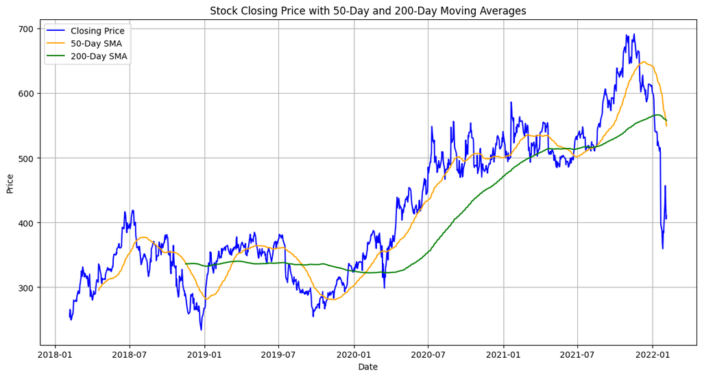

```python
# Calculate moving averages
df['SMA_50'] = df['Close'].rolling(window=50).mean()
df['SMA_200'] = df['Close'].rolling(window=200).mean()

# Plot the closing price with moving averages
plt.figure(figsize=(14, 7))
plt.plot(df.index, df['Close'], label='Closing Price', color='blue')
plt.plot(df.index, df['SMA_50'], label='50-Day SMA', color='orange')
plt.plot(df.index, df['SMA_200'], label='200-Day SMA', color='green')
plt.title('Stock Closing Price with 50-Day and 200-Day Moving Averages')
plt.xlabel('Date')
plt.ylabel('Price')
plt.legend()
plt.grid(True)
plt.show()
```

Explanation:

Closing Price: The blue line represents the daily closing price of the stock. 50-Day SMA (Simple Moving Average): The orange line shows the average closing price over the past 50 days. It smooths out short-term fluctuations and highlights the short-term trend. 200-Day SMA: The green line shows the average closing price over the past 200 days. It provides a view of the long-term trend. Purpose: Moving averages help in identifying trends and potential buy/sell signals. When the short-term SMA crosses above the long-term SMA, it may indicate a bullish signal (buy). Conversely, when it crosses below, it may indicate a bearish signal (sell).

## Daily Returns Analysis

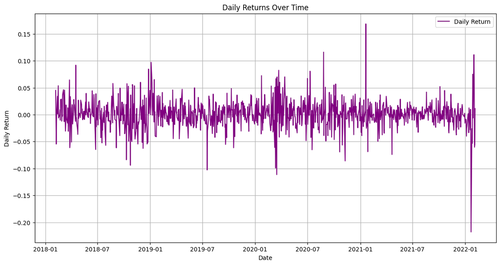

```python
# Calculate daily returns
df['Daily Return'] = df['Close'].pct_change()

# Plot daily returns
plt.figure(figsize=(14, 7))
plt.plot(df.index, df['Daily Return'], label='Daily Return', color='purple')
plt.title('Daily Returns Over Time')
plt.xlabel('Date')
plt.ylabel('Daily Return')
plt.legend()
plt.grid(True)
plt.show()
```

Explanation:

Daily Return: The purple line represents the percentage change in the closing price from one day to the next. Purpose: Analyzing daily returns helps in understanding the stock's volatility and risk. Frequent and large fluctuations indicate high volatility, which might suggest higher risk but also potentially higher reward.

## Histogram of Dail Returns

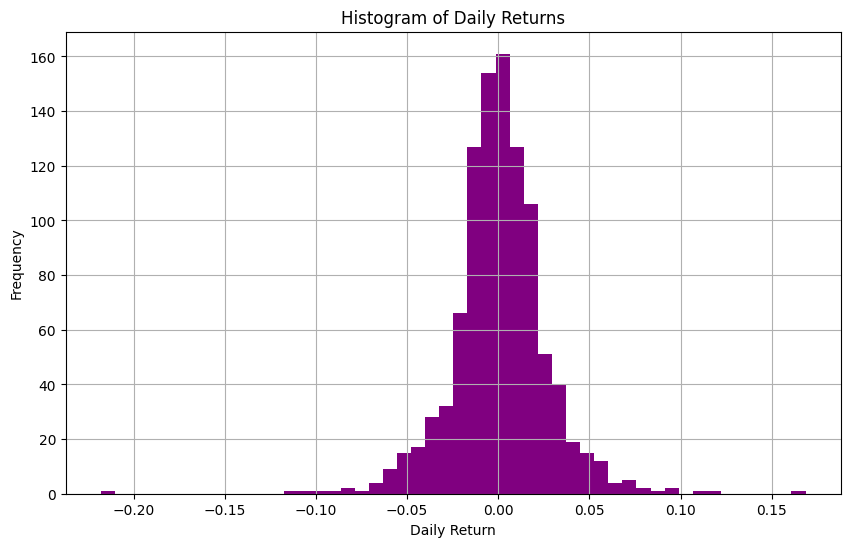

```python
# Plot histogram of daily returns
plt.figure(figsize=(10, 6))
plt.hist(df['Daily Return'].dropna(), bins=50, color='purple')
plt.title('Histogram of Daily Returns')
plt.xlabel('Daily Return')
plt.ylabel('Frequency')
plt.grid(True)
plt.show()
```

Explanation:

Histogram: The bars show the frequency of daily returns falling within specific ranges. Shape and Spread: The shape of the histogram gives an idea of the distribution of daily returns. A normal distribution would appear as a bell curve. Skewness and Kurtosis: The histogram can also reveal skewness (asymmetry) and kurtosis (peakedness) in the returns. Purpose: This visualization helps in assessing the probability of different return levels, understanding the risk and potential reward, and detecting any anomalies.

## Box Plot of Stock Prices

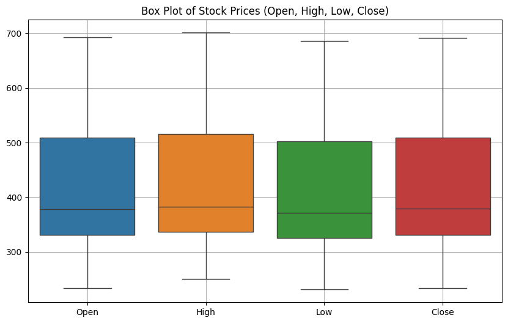

```python
# Plot box plot of Open, High, Low, Close prices
plt.figure(figsize=(10, 6))
sns.boxplot(data=df[['Open', 'High', 'Low', 'Close']])
plt.title('Box Plot of Stock Prices (Open, High, Low, Close)')
plt.grid(True)
plt.show()
```

Explanation:

Box Plot Components: Box: Represents the interquartile range (IQR) which contains the middle 50% of the data. Median Line: The line inside the box represents the median (50th percentile). Whiskers: Extend to the smallest and largest values within 1.5 times the IQR from the lower and upper quartiles, respectively. Outliers: Data points outside the whiskers are plotted as individual points and represent outliers. Comparison: Shows the distribution and range of Open, High, Low, and Close prices. Purpose: The box plot helps in understanding the central tendency, spread, and skewness of the stock prices, as well as identifying any potential outliers.

# Data Preparation

```python
import pandas as pd

# Load and prepare the data
df = pd.read_csv(r'C:\Users\Dell\Downloads\stock.csv')
df['Date'] = pd.to_datetime(df['Date'])
df.set_index('Date', inplace=True)

# Select the closing price for prediction
data = df['Close']
```

# Model Training

```python
from statsmodels.tsa.arima.model import ARIMA
import matplotlib.pyplot as plt

# Split the data into training and test sets
train_size = int(len(data) * 0.8)
train, test = data[:train_size], data[train_size:]

# Train the ARIMA model
model = ARIMA(train, order=(5, 1, 0))  # (p, d, q) parameters can be tuned
model_fit = model.fit()

# Print model summary
print(model_fit.summary())
```

```
                               SARIMAX Results
==============================================================================
Dep. Variable:                  Close   No. Observations:                  807
Model:                 ARIMA(5, 1, 0)   Log Likelihood               -3024.020
Date:                Sun, 09 Jun 2024   AIC                           6060.040
Time:                        17:24:45   BIC                           6088.192
Sample:                             0   HQIC                          6070.851
                                - 807
Covariance Type:                  opg
==============================================================================
                 coef    std err          z      P>|z|      [0.025      0.975]
------------------------------------------------------------------------------
ar.L1         -0.1079      0.035     -3.084      0.002      -0.176      -0.039
ar.L2          0.0072      0.031      0.232      0.817      -0.053       0.068
ar.L3         -0.0222      0.033     -0.664      0.506      -0.088       0.043
ar.L4          0.0875      0.033      2.622      0.009       0.022       0.153
ar.L5         -0.0904      0.027     -3.411      0.001      -0.142      -0.038
sigma2       106.2468      2.670     39.800      0.000     101.015     111.479
===================================================================================
Ljung-Box (L1) (Q):                   0.06   Jarque-Bera (JB):              1704.53
Prob(Q):                              0.81   Prob(JB):                         0.00
Heteroskedasticity (H):               1.95   Skew:                             0.44
Prob(H) (two-sided):                  0.00   Kurtosis:                        10.07
===================================================================================

Warnings:
[1] Covariance matrix calculated using the outer product of gradients (complex-step).
```

```python
!pip install statsmodels
```

[output not shown]

[output cut: 96 more lines]

[output not shown]

# Forecasting

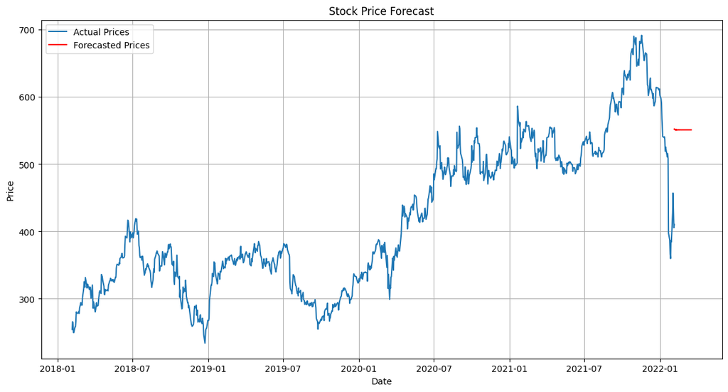

```python
# Forecast the future prices
forecast_steps = 30  # Number of days to forecast
forecast = model_fit.forecast(steps=forecast_steps)

# Plot the actual and forecasted prices
plt.figure(figsize=(14, 7))
plt.plot(data.index, data, label='Actual Prices')
plt.plot(pd.date_range(data.index[-1], periods=forecast_steps, freq='B'), forecast, label='Forecasted Prices', color='red')
plt.title('Stock Price Forecast')
plt.xlabel('Date')
plt.ylabel('Price')
plt.legend()
plt.grid(True)
plt.show()
```

# Investment Analysis

```python
# Investment analysis based on forecasted prices
buy_threshold = 0.02  # 2% increase as a buy signal
sell_threshold = -0.02  # 2% decrease as a sell signal

# Calculate daily returns from the forecast
forecast_returns = forecast.pct_change()

# Identify buy and sell signals
buy_signals = forecast_returns[forecast_returns > buy_threshold]
sell_signals = forecast_returns[forecast_returns < sell_threshold]

print("Buy Signals (Dates and Predicted Returns):")
print(buy_signals)

print("\nSell Signals (Dates and Predicted Returns):")
print(sell_signals)
```

```
Buy Signals (Dates and Predicted Returns):
Series([], Name: predicted_mean, dtype: float64)

Sell Signals (Dates and Predicted Returns):
Series([], Name: predicted_mean, dtype: float64)
```

# Explanation

## Data Preparation:

We load the dataset and preprocess it by converting the 'Date' column to datetime format and setting it as the index. We select the 'Close' price for the prediction model.

## Model Training:

The dataset is split into training (80%) and test (20%) sets. An ARIMA model is trained on the training data with specified parameters (p=5, d=1, q=0). These parameters can be tuned based on model performance.

### Project Analysis and Conclusion

#### Data Preparation

In this project, we started by preparing the dataset for analysis. The data contained stock prices with columns for Open, High, Low, Close, Adjusted Close, and Volume, along with the date. We converted the 'Date' column to a datetime format and set it as the index for better time series analysis. The 'Close' price was selected for prediction, as it is the most commonly analyzed price in stock market forecasting.

#### Model Training

We used the ARIMA (AutoRegressive Integrated Moving Average) model for time series forecasting. ARIMA is a popular method for analyzing and predicting future values in a time series. The dataset was split into training and test sets, with 80% of the data used for training the model and 20% for testing. The model parameters (p, d, q) were set to (5, 1, 0) based on initial analysis, though these parameters can be further tuned for better performance.

### Tips for Buying and Trading Stocks

1. **Diversify Your Portfolio**: Spread your investments across various stocks, sectors, and asset classes to reduce risk.
2. **Do Your Research**: Before investing in any stock, conduct thorough research on the company's financial health, market position, and growth prospects. Read financial statements, analyst reports, and news articles.
3. **Use Technical and Fundamental Analysis**: Combine technical analysis (e.g., chart patterns, moving averages) with fundamental analysis (e.g., earnings, revenue growth) to make more informed decisions.
4. **Set Clear Investment Goals**: Define your investment goals, risk tolerance, and time horizon. Decide whether you are looking for short-term gains or long-term growth.
5. **Stay Informed**: Keep up with market news, economic indicators, and global events that may impact stock prices. Use financial news websites, market reports, and stock analysis tools.
6. **Use Stop-Loss Orders**: Protect your investments by setting stop-loss orders to limit potential losses. This automatically sells a stock when it reaches a certain price, preventing further losses.
7. **Be Patient**: Stock market investing requires patience. Avoid making impulsive decisions based on short-term market fluctuations. Stick to your investment strategy and give your investments time to grow.
8. **Monitor Your Portfolio**: Regularly review your portfolio to ensure it aligns with your investment goals. Rebalance your portfolio as needed to maintain your desired asset allocation.
9. **Consider Professional Advice**: If you are unsure about your investment strategy or need personalized advice, consider consulting a financial advisor.

By following these tips and leveraging forecasting tools like the ARIMA model, you can enhance your investment strategy and make more informed decisions in the stock market.